# Análisis de Tickets de Supermercado: Mini Proyecto 2025

Tratamiento de datos. Grado en Ciencia de Datos - UV

2025-05-13

$$\text{Neus Ferrer Font, Marta Navarro García, Alba Rodríguez Simón, Mohammed Aissa Djellouli}$$
$$\text{Héctor Balbastre Aparisi, Joan Ruiz Ripoll, Carlos Santiago Martinez Torres}$$

# 1 Introducción

En este proyecto se plantea realizar el análisis de tickets del supermercado Mercadona, los cuales fueron recolectados por los estudiantes del grado de Ciencia de datos y otros de cursos anteriores.

## 1.1 Contexto

Actualmente las grandes empresas gestionan volúmenes significativos de productos, lo que conlleva elevados costes asociados al transporte y almacenamiento. Por este motivo, resulta fundamental optimizar cada etapa del proceso logístico. Con base en nuestro conocimiento en Big Data, nuestro equipo se enfocará en analizar y comprender las tendencias de los consumidores, con el objetivo de reducir costes operativos.

## 1.2 Grupo

Nuestro objetivo al responder estas preguntas es profundizar en los hábitos y preferencias reales de los consumidores a partir del análisis de tickets de compra. Al extraer patrones y correlaciones dentro de estos datos, buscamos generar conocimiento útil para anticipar comportamientos, mejorar la planificación comercial y ajustar la oferta a la demanda real. Esta aproximación nos permitirá aportar valor estratégico desde el análisis de datos, con el foco puesto en reducir ineficiencias, mejorar la toma de decisiones y apoyar la sostenibilidad operativa del negocio desde una perspectiva basada en la evidencia.

# 2 Material y métodos

## 2.1 Carga de librerías

Para la carga de librerías, haremos uso del paquete pacman de R, que es eficiente para la carga e instalación de las mismas. En este proyecto, utilizaremos las librerias pdftools, tidyverse, readxl, lubridate, visdat, entre otras.

## 2.2 Carga de datos

Todos nuestros datos están almacenados en la carpeta *data*. Previamente se hizo una lectura de todos los ficheros con el archivo *ExtraccionDatos.Rmd* y se almacenó la información en el archivo *data/RegistrosMercadona.RData*. Antes de la extracción de los datos, fue necesario preguntarse: ¿Qué información queremos almacenar? ¿Cómo vamos a almacenar la información para responder a las preguntas que nos habíamos planteado?

*Nota:* A lo largo de la extracción de los datos, se implementaron funciones para ser recursivos, además de facilitar la lectura del código y hacer una carga completa (barrido) de los datos contenidos en los ficheros.

Dentro de cada fichero, encontramos dos partes fundamentales. La primera, es el encabezado. Contiene información sobre la compra en general. Por ejemplo, la ubicación de la tienda, fecha y hora de compra, y número de ticket. En la segunda parte, nos encontramos con el bloque de los productos. En ella se describe el producto comprado, la cantidad y el importe pagado.

Para la lectura de los productos, identificamos dos filtros. El primero, es si el ticket incluía parking o no. Este ‘producto’ estaba listado al final, lo que nos permitía de alguna forma reducir el listado de productos e identificar si había o no parking.

El segundo filtro, permitía saber si se compró pescado o no. Este filtro fue de gran utilidad dado que por la naturaleza de negocio de Mercadona, los tickets y los productos vienen clasificados en 2 categorías: *venta por unidad* y *venta al peso* para pescado y, frutas y verduras.

Si en el ticket se registró la compra de pescado, ya podíamos establecer que a partir de ese filtro, los productos que estuvieran por debajo de esa línea, serían al peso. Y los que no, serían por unidad. Una vez que se identificara el tipo de producto, unitario o al peso, ya sería más fácil identificar la categoría a la que pertenece, por el formato en que fue registrado el producto en el ticket.

## 2.3 Ficheros no leidos

Solo los ficheros con el formato correcto, serían tratados. Es decir, aquellos ficheros que tuvieran un escaner, foto u otro formato de factura distinto al formato de Mercadona, no serían tratados. Para identificarlos y corroborar su contenido, hemos almacenado el nombre del fichero en un dataframe diferente *NoLeido*.

## 2.4 Presentación parcial de los datos

Esta es una representación sobre cómo se almacenaron los datos para empezar a trabajar sobre ellos. En la Tabla 2.1 podemos ver todas las tiendas en las que se han hecho las compras. En total, se han registrado 34 tiendas.

Table 2.1: Tabla de tiendas leidas

| IdTienda | Direccion | CodigoPostal | Municipio | Telefono |
| --- | --- | --- | --- | --- |
| 2916 | CTRA. GARRUCHA A VERA S/N | 04630 | GARRUCHA | 950133380 |
| 2233 | AVDA. VALENCIA 41 | 03830 | MURO DE ALCOY | 966516066 |
| 4530 | C/ ALICANTE 83 | 03801 | ALCOI/ALCOY | 965366422 |
| 3075 | C/ MENORCA (C.C. AQUA) 19 | 46023 | VALENCIA | 963319378 |
| 3095 | C/ VALENCIA S/N | 03178 | BENIJOFAR | 966713008 |
| 4478 | AVDA. DEL TEXTIL 21 | 46870 | ONTINYENT | 961484834 |
| 4347 | C/ PERIODISTA AZZATI 26 | 46520 | SAGUNT/SAGUNTO | 961485847 |
| 4583 | C/ MANUEL CANDELA 16 | 46021 | VALENCIA | 961624385 |
| 3957 | C/ PINTOR MAELLA 3 | 46023 | VALENCIA | 962564516 |
| 2473 | AVDA. CARDENAL BENLLOCH 91 | 46021 | VALENCIA | 963612915 |

En la Tabla 2.2 se muestran los productos que fueron leídos, identificando el ticket de compra, descripción, el tipo de producto, cantidad, entre otros.

Table 2.2: Tabla de productos leidos

| IdFactura | DescripcionProducto | Cantidad | PrecioUnitario | ImporteProducto | TipoProducto |
| --- | --- | --- | --- | --- | --- |
| 520925 | DONACIÓN | 5 | 1,00 | 5,00 | Unitario |
| 520925 | BARREÑO | 1 | 2,20 | 2,20 | Unitario |
| 520925 | PALO ANTIDESLIZANTE | 3 | 1,90 | 5,70 | Unitario |
| 520925 | MULTIUSOS | 1 | 2,55 | 2,55 | Unitario |
| 520925 | AGUA MINERAL | 2 | 0,73 | 1,46 | Unitario |
| 520925 | B.BASURA EXT.C.FÁCIL | 2 | 1,60 | 3,20 | Unitario |
| 520925 | ESCURRE FÁCIL | 1 | 2,85 | 2,85 | Unitario |
| 520925 | CUBO FREGAR C/RUEDAS | 1 | 3,85 | 3,85 | Unitario |
| 520925 | FRIEGASUELOS PINO | 1 | 0,95 | 0,95 | Unitario |
| 520925 | FIBRAS CRUZADAS | 2 | 2,10 | 4,20 | Unitario |

# 3 Limpieza de datos

## 3.1 Valores NA

En principio, dada la naturaleza del ejercicio, de extracción y carga de los datos, no deberían haber valores nulos o NA. Sin embargo, es necesario verificar.

## 3.2 Problemas con tipos de datos

Con *glimpse* podemos ver algunos datos del dataframe, además de comprobar que cada columna tiene su tipo de dato adecuado. En el dataframe de tienda, podriamos poner tanto el id, el código postal, y el teléfono como números enteros. Pero, ya que no tendría sentido realizar operaciones propias de los números enteros con estos datos, no será necesario.

Con los dataframes Compra y Producto, no podemos hacer lo mismo. Las variables como *Fecha*, *ImporteTotal*, *Cantidad* y *PrecioUnitario*, deben tener el dato correspondiente para realizar las operaciones necesarias. Por ejemplo, dentro de las variables numéricas, es importante sustituir las comas por puntos para identificar los decimales y transformar correctamente el dato. Por último, el *TipoProducto*, *Parking* y la variable *Tarjeta*, que serán de tipo categórico.

Para finalizar hacemos una verificacion sobre los valores repetidos. En principio, no deberían haber valores repetidos, ya que al hacer el registro de los datos, se evito este problema. Sin embargo, usando *unique* podemos asegurarnos.

# 4 Resultados

## 4.1 Análisis de variables

Una vez tenemos limpios los datos, procedemos a analizarlos. Debemos tener en cuenta que dada la naturaleza de los datos y el desarrollo del trabajo, el análisis de las variables y las relaciones entre ellas, las veremos en profundidad en los apartados siguientes. Sin embargo, para tener un acercamiento a los datos, se puede ver la Figura 4.1.

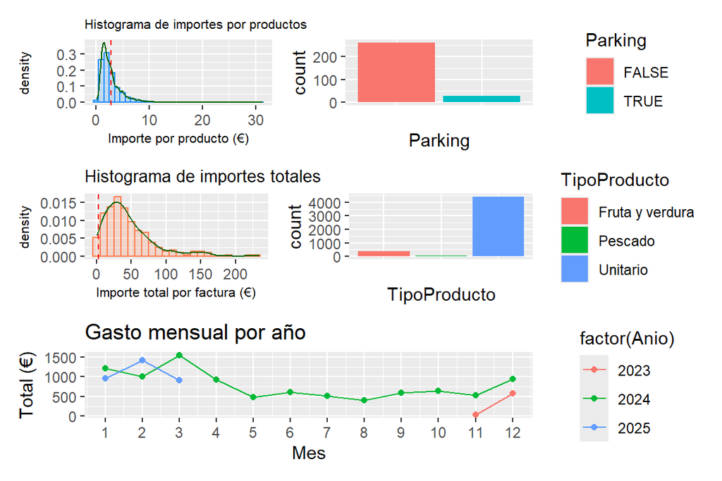

Figure 4.1: Análisis de variables

Mercadona se caracteriza por ofrecer productos a precios bajos. Por ejemplo, podemos ver como los importes por productos, tienen un sesgo por derecha hacia precios menores a los 10 euros, dónde su media no supera los 5 euros. Por otro lado, los productos que más se han de comprar en Mercadona, son los unitarios. Los pescados y, frutas y verdura, no tienen la misma proporción.

A pesar de que no se presentan gran cantidad de datos para ver la variación de los precios en los productos por año, y su comportamiento y/o frecuencia de compra por cada mes, vemos que hay una tendencia a comprar entre los primeros 4 meses del año y el final.

## 4.2 Preguntas planteadas

1. ¿Qué combinaciones de productos se compran con mayor frecuencia en una misma factura?

Para las combinaciones de productos, será necesario saber el *id de factura* y la *descripción del producto*. Una vez identificados, generamos todas las combinaciones entre los productos por factura, para saber la frecuencia en todas las facturas.

En la Figura 4.2, vemos que una de las combinaciones de productos que más se repite es ALMENDRA NATURAL + CACAHUETE CHOCOLATE, con un total de 16 veces.

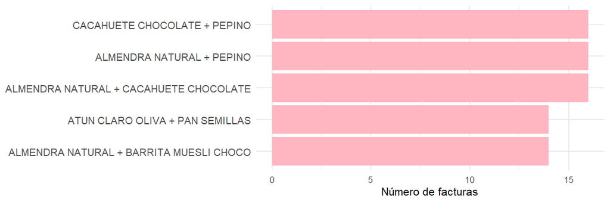

Figure 4.2: Combinaciones de productos más frecuentes

2. ¿Qué productos mantienen un volumen de ventas estable, independientemente de cambios en su precio unitario?

Para determinar los productos que mantienen un volumen de ventas estable, analizaremos el *cv_precio*, que es el coeficiente de variación del precio. Mide la variabilidad relativa del precio del producto (desviación estándar sobre media). Cuanto más bajo, más estable es el precio. También, la *correlación* entre el precio unitario y la cantidad vendida. Mide si las ventas aumentan o disminuyen cuando cambia el precio.

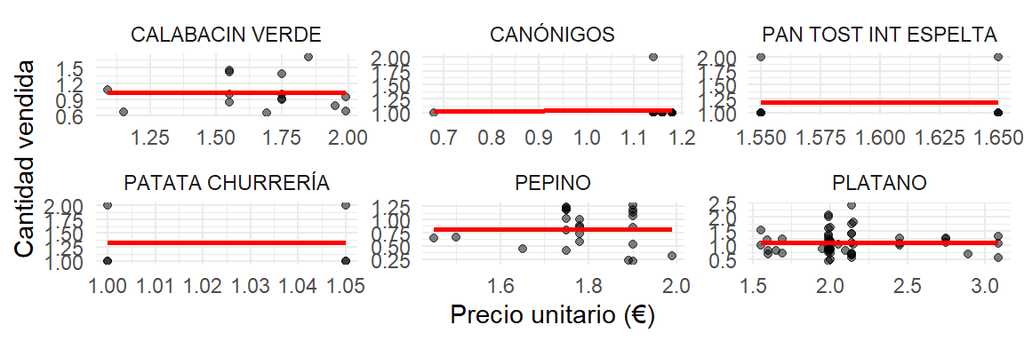

Figure 4.3: Relación precio-cantidad para productos con ventas estables

En la Figura 4.3, se visualiza cómo varían las ventas según el precio para los 6 productos más estables. Como estos productos tienen precios muy constantes (bajo cv_precio), los puntos están cercanos al eje X. Las líneas rojas muestran la tendencia general: si sube o baja la venta cuando cambia el precio.

En general, la mayoría de los productos tienen precios bastante estables (cv_precio < 0.1), lo cual es bueno para el control de precios. Las correlaciones son muy bajas, cercanas a 0. Esto sugiere que, para estos productos, el precio no influye fuertemente en la cantidad vendida.

3. ¿Cuál es el número promedio de tickets por hora y el gasto promedio por compra, según el día y la hora?

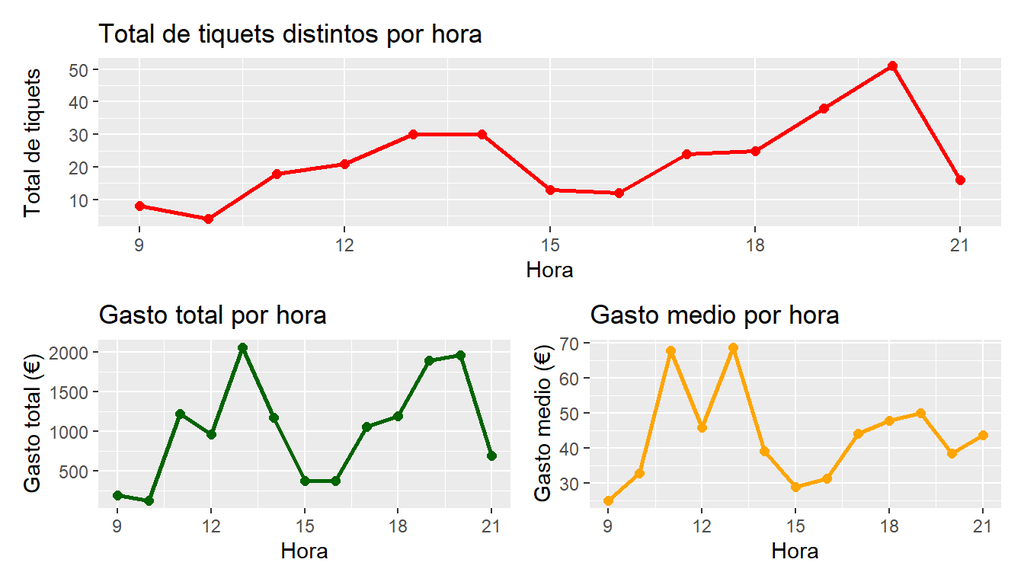

Figure 4.4: Análisis de tickets y gasto

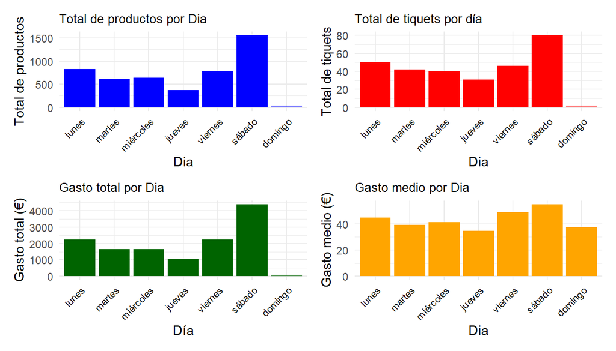

Figure 4.5: Patrones de compra

Si hablamos de los días de la semana, el gasto medio por dia esta muy balanceado sin casi variación entre los días, pero claramente podemos 2 días que salen de la norma en el resto de aspectos, siendo estos sábado y jueves, como día con más ventas y beneficios claramente y el jueves siendo el día con menos. Véase Figura 4.5.

4.¿Qué patrones de compra se observan hacia inicio/fin de mes? ¿Cuántas compras incluyen parking?

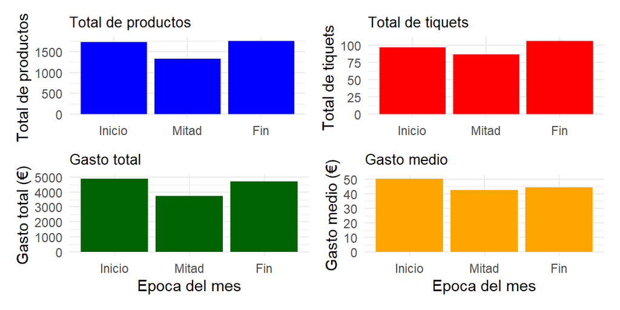

Figure 4.6: Patrones de compra por epoca de mes

Como se ve en la Figura 4.6, analizando las épocas de los meses, destacamos que las ventas bajan a mitad de mes. Podemos inferir que esto se debe a que este periodo no coincide con la entrega de los sueldos.

Table 4.1: Compras que incluyen parking

| Parking | Total compras |
| --- | --- |
| FALSE | 261 |
| TRUE | 29 |

En lo que al parking respecta, claramente no es muy usado ya que en la Tabla 4.1 vemos que el 90% de las compras no registran, pero esto puede ser debido a la edad de quienes generan los datos y puede no ser información concluyente. Si así lo fuera habría que cuestionar si el gasto de la creación del parking sale rentable a muy largo plazo.

5. ¿Cuáles son los 5 productos, de los vendidos por unidades, con más ventas? ¿Cuántas unidades de cada uno se han vendido?

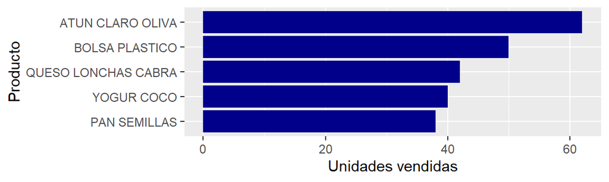

Figure 4.7: Top 5 productos unitarios mas vendidos

En los productos unitario más vendidos, Figura 4.7, observamos que el ATÚN CLARO EN ACEITE DE OLIVA encabeza la lista con diferencia. Esto es esperable, ya que es un alimento no perecedero (no se estropea fácilmente con el tiempo), versátil (tiene muchos usos) y de consumo muy habitual en los hogares.

En segundo lugar aparece la BOLSA DE PLÁSTICO, lo que indica que se está contabilizando como producto individual cada vez que un cliente la compra en caja, algo muy común en supermercados que cobran por bolsa. A continuación, encontramos productos como QUESO EN LONCHAS DE CABRA, YOGUR DE COCO y PAN DE SEMILLAS. Son todos productos cotidianos, vinculados a desayunos, meriendas o cenas rápidas, y que suelen venderse en unidades individuales o en envases pequeños.

6. Si consideramos la categoría de FRUTAS Y VERDURAS, ¿cuáles son los 5 productos más vendidos? ¿Cuántos kilos se han vendido de cada uno de estos productos?

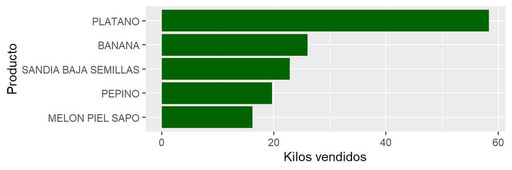

Figure 4.8: Top 5 frutas y verduras mas vendidas

La Figura 4.8 refleja claramente una preferencia por productos frescos y saludables, que forman parte de la dieta diaria de muchas personas. Además, la estacionalidad de algunos de ellos sugiere que este tipo de análisis puede ser útil también para estudiar patrones de compra vinculados al calendario.

7. Si consideramos la categoría de PESCADO, ¿Cuáles son los 5 productos más vendidos? ¿Cuántos kilos se han vendido de cada uno de estos productos?

Para saber cuáles son los 5 productos más vendidos considerando únicamente la categoría pescado, debemos primero filtrar los datos para quedarnos solamente con la categoría *TipoProducto* y que esta contenga el valor de “Pescado”. Seguidamente calcularemos los kilos totales vendidos de cada producto y, por último mediante una suma nos quedaremos con los 5 productos más vendidos.

Table 4.2: Analisis categoria PESCADO

| DescripcionProducto | veces_comprado | kilos_totales |
| --- | --- | --- |
| BACALADILLA | 5 | 5.782 |
| SEPIA FRESCA | 5 | 2.642 |
| SEPIA LONJA | 4 | 2.792 |
| LENGUADO FRESC EUROP | 3 | 1.248 |
| SEPIA SUCIA REFRIG | 3 | 2.402 |

En la Tabla 4.2, los 5 productos más vendidos de la categoría pescado son la bacaladilla con una venta de 5.782 kg, la sepia fresca con 2.642 kg vendidos, la sepia lonja con 2.792 kg vendidos, el lenguado fresc europ con 1.248 kg vendidos y por último la sepia sucia, con 2.402 kg vendidos.

8. Muestra mediante un gráfico de líneas como ha variado el precio por kilo de las bananas y los plátanos en los tickets disponibles, a lo largo del tiempo.

Primero debemos unir las dos tablas *Compra* y *Producto* ya que en una se encuntra la descripción del producto y en otra la fecha, que nos interesa bastante para responder a la pregunta. Una vez unida, filtramos la descripción del producto para quedarnos unicamente con los productos “platano” y “banana”. Calculamos el precio medio del kilo por mes y representamos graficamente ya que es una forma muy fácil de interpretar los datos, y de ver la evolución del precio de estos dos productos a lo largo del tiempo.

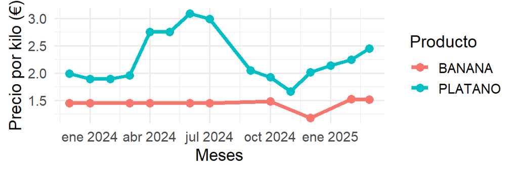

Figure 4.9: Evolucion mensual del precio por kilo

9. ¿Cuál es la procedencia de los tickets? ¿Qué ciudad/ pueblo tiene un mayor número de tickets?

Podemos ver en la Figura 4.10, los diferentes municipios de los que proceden los tickets, hay una gran variedad de localidades diferentes, la mayoria de Valencia, pero alguna que otra de Alicante o de las Islas Baleares, incluso de Almeria (Vera, Garrucha). Podemos ver que la ciudad con el mayor número de tickets es Valencia, seguido de Alboraia y después Burjassot, era algo que se podia esperar, la ciudad con más tickets es la ciudad de estudio y los alrededores, aparte de eso, podemos ver una gran cantidad de instancias de Alcoy y cercanias, y por último una gran variedad de provincias diferentes, sea tanto Valencia como Alicante, pero también Almeria y Baleares

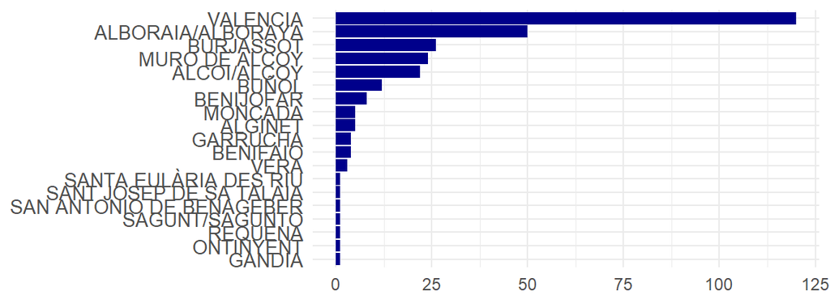

Figure 4.10: Tickets por municipio

10. Muestra mediante un diagrama el número de tickets recogidos cada día de las semana. ¿Si tuvieses que cerrar un día entre semana qué día lo harías?

Parece que lo obvio, según la Figura 4.11, sería cerrar los Domingos. Pero, por conocimiento del medio sabemos que la mayoria de las tiendas cierran ese mismo día; no es normal que las grandes cadenas de supermercados abran los Domingos. El siguiente mejor día para cerrar, es el jueves como podemos ver. Podríamos considerar también los martes o miércoles, ya que son los otros días con menos tiquets.

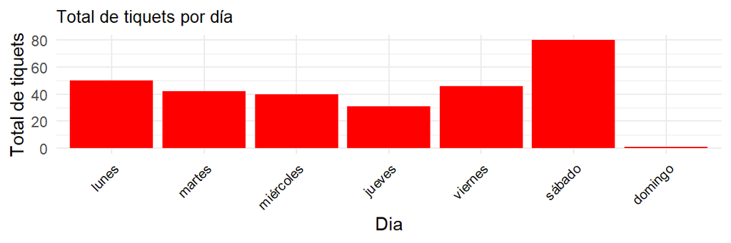

Figure 4.11: Tiquets por día

# 5 Conclusiones

Este proyecto se centró en el análisis de los tickets de compra de Mercadona con el objetivo de responder a preguntas clave relacionadas con los hábitos de consumo, los precios y los patrones de compra. A través del procesamiento y la visualización de los datos, fue posible identificar variaciones significativas en los precios unitarios de ciertos productos, así como tendencias en la frecuencia y el volumen de las compras.

En primer lugar, se observó que Mercadona tiende a mantener precios estables, mayormente por debajo de los 5 euros. Aunque en algunos momentos se registran picos en el número de tickets, productos comprados e importes totales, el gasto medio por compra rara vez supera los 50 euros.

Los resultados obtenidos permiten comprender mejor el comportamiento de consumo de los estudiantes del grado. Por ejemplo, se identificaron patrones claros en los hábitos de compra durante la semana. Es común que los estudiantes realicen sus compras el fin de semana, probablemente porque disponen de más tiempo. Además, se detectó una disminución en las compras los jueves, posiblemente porque muchos estudiantes regresan a sus hogares ese día.